# Assignment_03

Noah Scheider

10/21/2022

# 1 Exercise

Create a Shiny App or (alternatively) an R Markdown report exploring the (local, asymptotically optimal) bandwidth choice $h_{opt}(x)$ on slides 11 and 12 on simulated data example:

- locations $X$ from beta distribution rbeta(n,shape1,shape2)
- response values $Y = m(X) + \epsilon$ where
  - the regression function $m$ is given by $m(x) = sin(\frac{3}{x+0.3}))$
  - $\epsilon ~ \mathcal\sim {N}(0,\sigma^{2})$
- fix $\sigma^{2}$ at some visually appealing value (e.g. $\sigma^{2} = 1$ should be fine) explore how $h_{opt}(x)$ behaves depending on the following parameters (in case of a Shiny App, these will be sliders for the user to tweak):
  - sample size $n$
  - location $x$
  - beta parameters shape1 and shape2
- visualize (local, asymptotically optimal) bandwidth
  - also find a way to visually incorporate the beta density

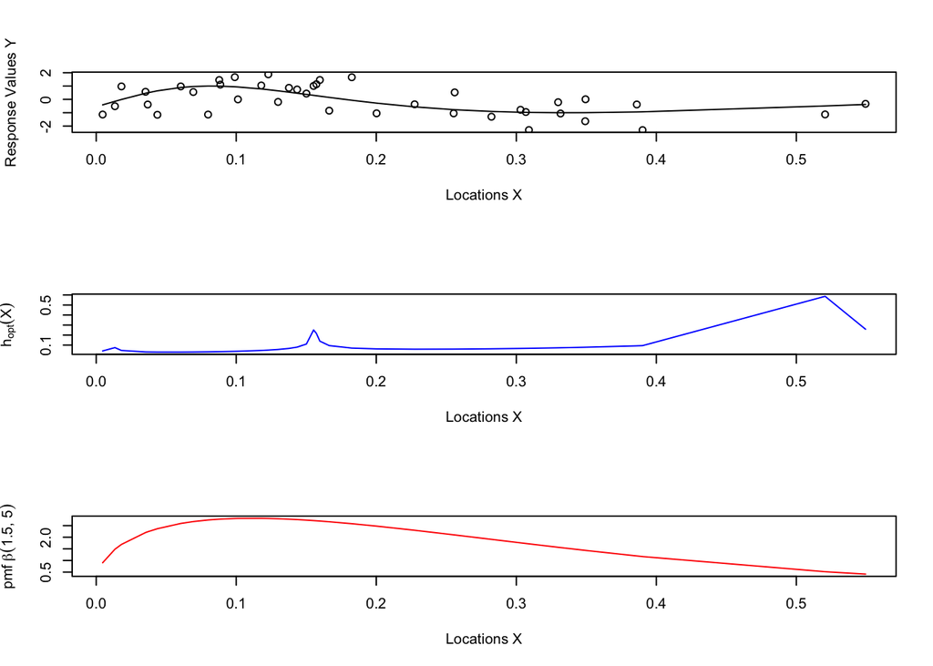

Figure 1.1: Figure shows behaviour of h_opt when choosing a sample of beta distributed random variables with sample size = 40.00, shape1 = 1.50, shape2 = 5.00

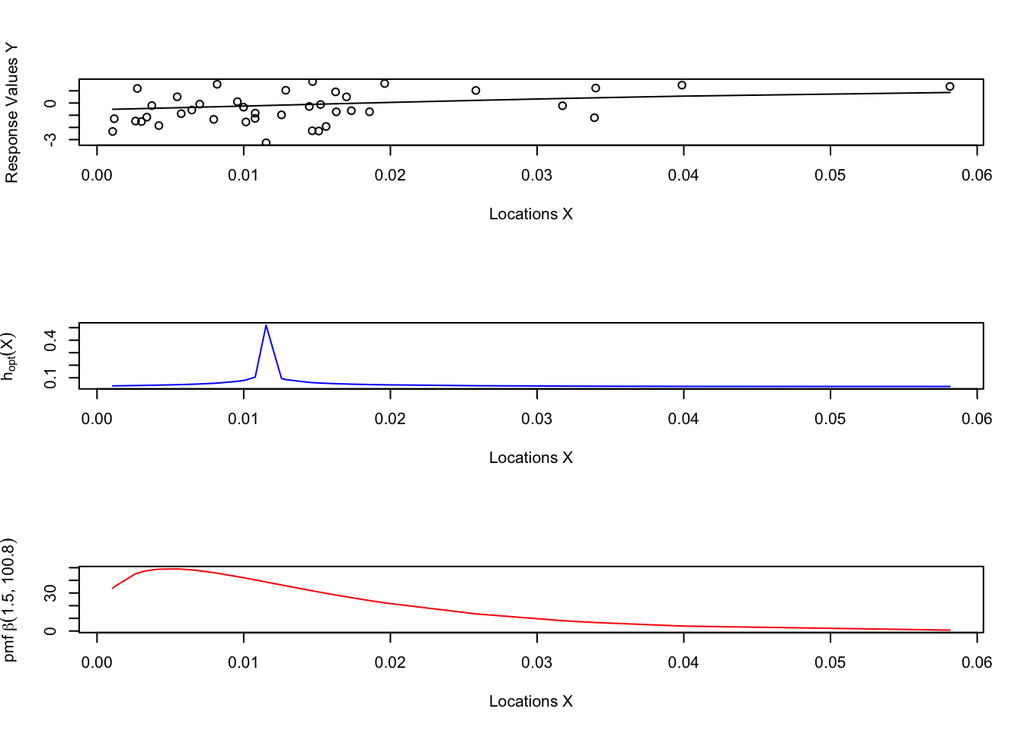

Figure 1.2: Figure shows behaviour of h_opt when choosing a sample of beta distributed random variables with sample size = 40.00, shape1 = 1.50, shape2 = 100.80

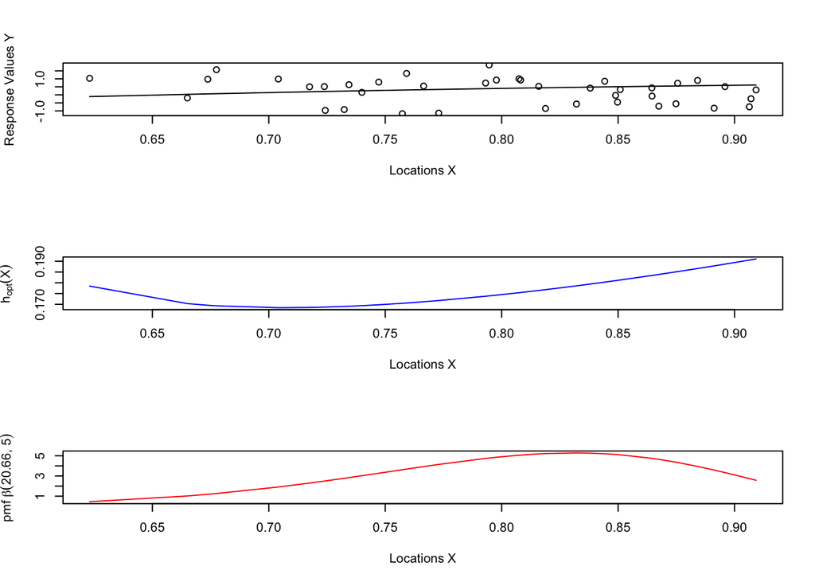

Figure 1.3: Figure shows behaviour of h_opt when choosing a sample of beta distributed random variables with sample size = 40.00, shape1 = 20.66, shape2 = 5.00

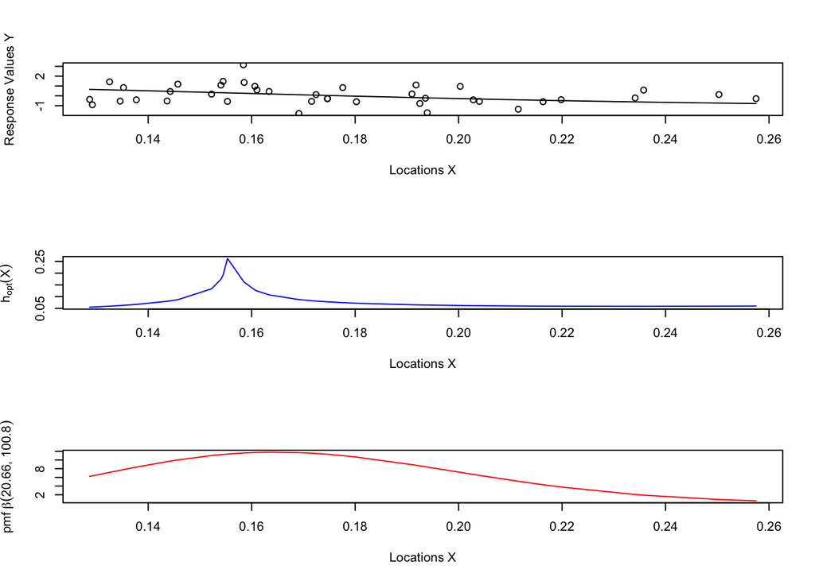

Figure 1.4: Figure shows behaviour of h_opt when choosing a sample of beta distributed random variables with sample size = 40.00, shape1 = 20.66, shape2 = 100.80

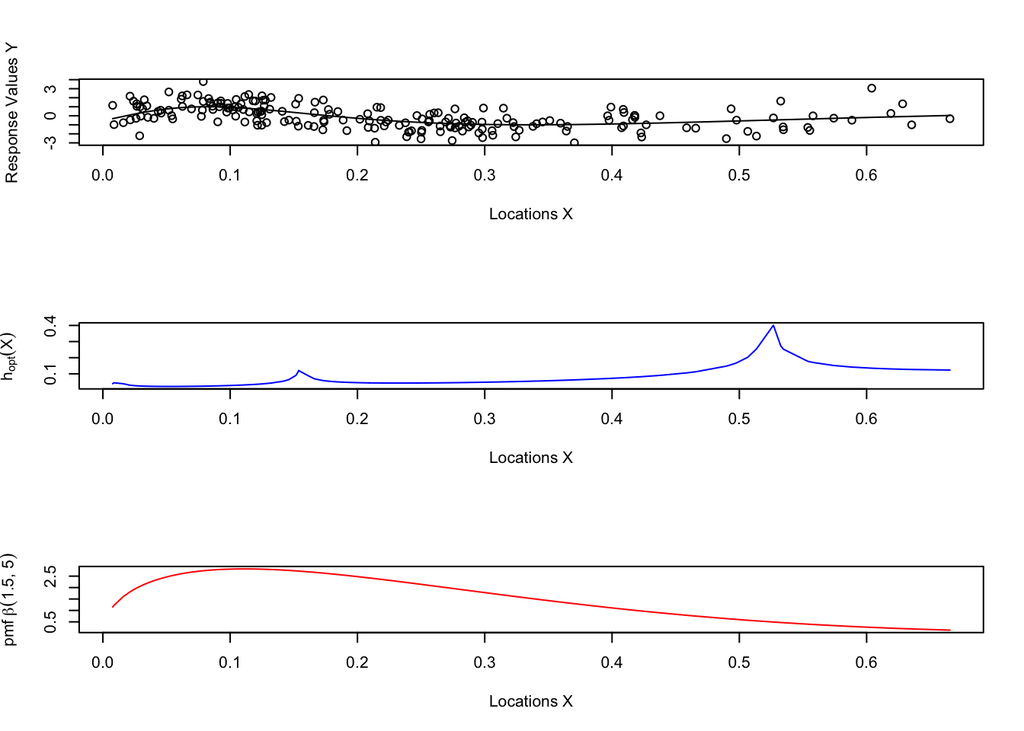

Figure 1.5: Figure shows behaviour of h_opt when choosing a sample of beta distributed random variables with sample size = 200.00, shape1 = 1.50, shape2 = 5.00

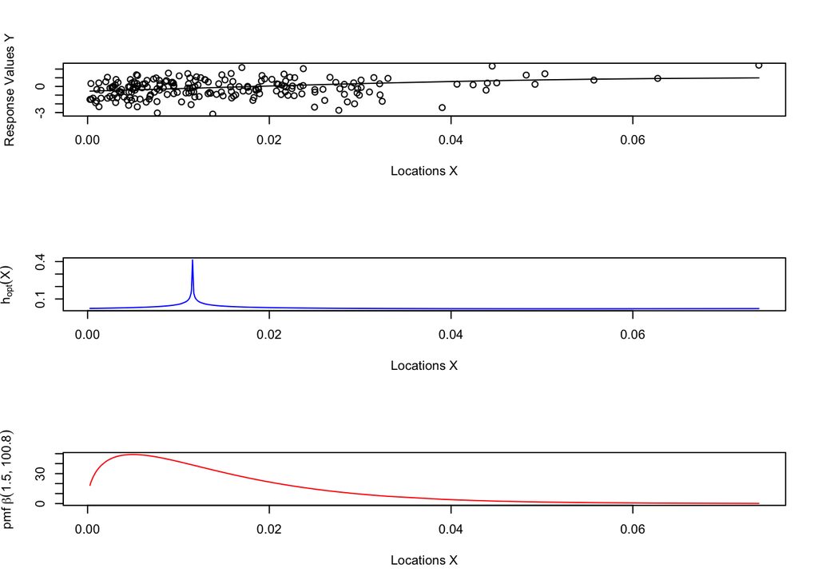

Figure 1.6: Figure shows behaviour of h_opt when choosing a sample of beta distributed random variables with sample size = 200.00, shape1 = 1.50, shape2 = 100.80

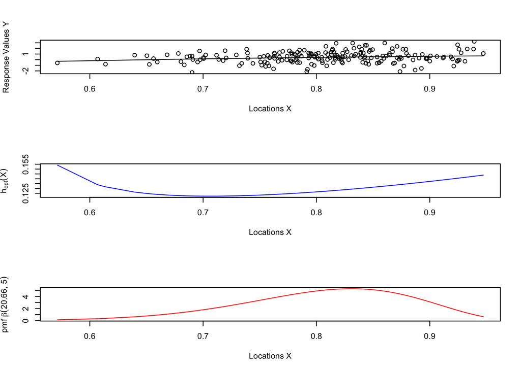

Figure 1.7: Figure shows behaviour of h_opt when choosing a sample of beta distributed random variables with sample size = 200.00, shape1 = 20.66, shape2 = 5.00

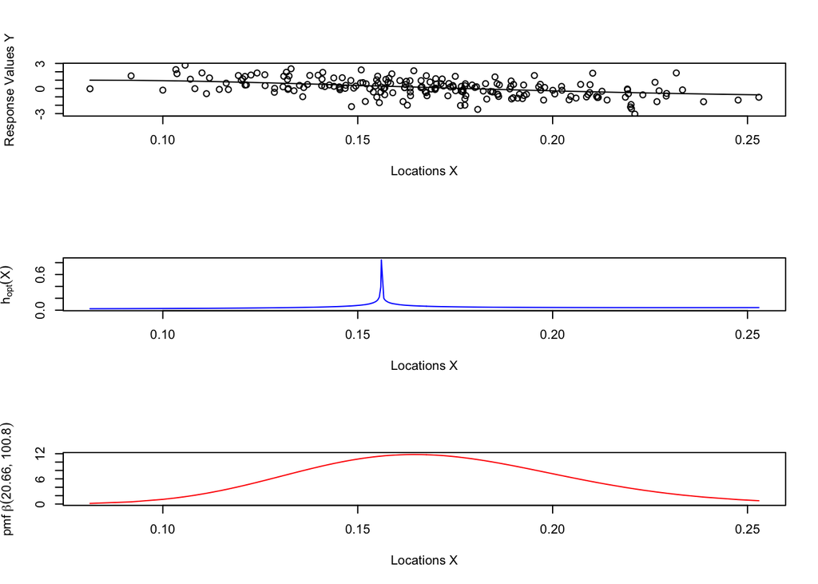

Figure 1.8: Figure shows behaviour of h_opt when choosing a sample of beta distributed random variables with sample size = 200.00, shape1 = 20.66, shape2 = 100.80

# 2 Conclusion